# Lab 21: Sixteen Personality Factors I

## Instructions

Below you will find several empty R code scripts and answer prompts. Your task is to fill in the required code snippets and answer the corresponding questions.

## Sixteen Personality Factors: Pick Your Trait

Over the next two classes we are going to be looking at survey response data from the Sixteen Personality Factor Questionnaire in order to practice our skills at statistical inference:

The dataset use the following fields:

- age: respondent’s age in years
- gender: respondent’s self-selected gender
- country: two letter IATA code for the respondent’s IP
- elapsed: time taken to complete quiz in seconds
- warmth: personality score from 1-20
- reasoning: personality score from 1-20
- emotional_stability: personality score from 1-20
- dominance: personality score from 1-20
- liveliness: personality score from 1-20
- rule_consciousness: personality score from 1-20
- social_boldness: personality score from 1-20
- sensitivity: personality score from 1-20
- vigilance: personality score from 1-20
- abstractedness: personality score from 1-20
- privateness: personality score from 1-20
- apprehension: personality score from 1-20
- openness_to_change: personality score from 1-20
- self_reliance: personality score from 1-20
- perfectionism: personality score from 1-20
- tension: personality score from 1-20
- baseline: average score across all 16 personality traits

*To start with, select a particular trait that you will use for the first bank of questions. I suggest picking something that popped out when you took the test. You can pick any of the 16 other than sensitivity.*

Produce a bar plot of the personality scores for your trait.

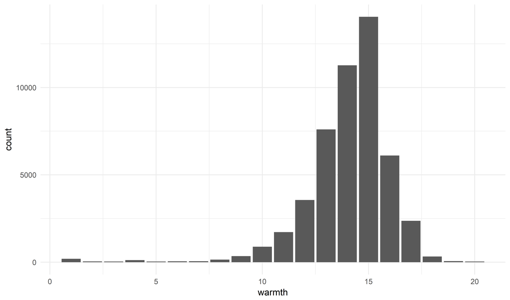

Describe the distribution. Why does a bar plot work here even though the variable is numeric?

**Answer**: Most of the people fall around the 15 score, between 12 and 15. I think the bar plot works here because the data is based on percentiles, so the bar shows where people fall within that type of range.

Produce a confidence interval for the mean of your trait.

```
##
## Call:
## lm_basic(formula = warmth ~ 1, data = pf)
##
## Residuals:
##      Min       1Q   Median       3Q      Max
## -13.0639  -1.0639  -0.0639   0.9361   5.9361
##
## Coefficients:
##             Estimate 2.5 % 97.5 %
## (Intercept)    14.06 14.05  14.08
##
## Residual standard error: 2.023 on 49059 degrees of freedom
```

Now, produce a dataset that consists only of responses from the country of Hungary. The 2-letter country code for Hungary is “HU”. Produce a confidence interval for your trait on the Hungarian dataset.

```
## # A tibble: 55 x 21
##      age gender country elapsed warmth reasoning emotional_stability
##    <int> <chr>  <chr>     <int>  <dbl>     <dbl>               <dbl>
##  1    23 female HU         4214   11.0      14.0                12.0
##  2    28 female HU          649   15.0      16.0                12.0
##  3    35 male   HU          721   10.0      14.0                13.0
##  4    17 female HU         3624   15.0      14.0                11.0
##  5    53 male   HU          929   15.0      14.0                13.0
##  6    32 female HU         1099   10.0      14.0                11.0
##  7    46 male   HU         4511   15.0      13.0                12.0
##  8    18 female HU          606   14.0      14.0                14.0
##  9    23 male   HU          492   14.0      14.0                14.0
## 10    37 female HU         1691   12.0      13.0                11.0
## # ... with 45 more rows, and 14 more variables: dominance <dbl>,
## #   liveliness <dbl>, rule_consciousness <dbl>, social_boldness <dbl>,
## #   sensitivity <dbl>, vigilance <dbl>, abstractedness <dbl>,
## #   privateness <dbl>, apprehension <dbl>, openness_to_change <dbl>,
## #   self_reliance <dbl>, perfectionism <dbl>, tension <dbl>,
## #   baseline <dbl>
```

```
##
## Call:
## lm_basic(formula = warmth ~ 1, data = hungary)
##
## Residuals:
##     Min      1Q  Median      3Q     Max
## -6.1273 -1.1273 -0.1273  1.8727  3.8727
##
## Coefficients:
##             Estimate 2.5 % 97.5 %
## (Intercept)    13.13 12.55  13.71
##
## Residual standard error: 2.152 on 54 degrees of freedom
```

What do you notice about this confidence interval compared to the original one? Can you explain why this is the case?

**Answer**: The previous confidence interval lower and upper bounds were very tight, different by only 0.03 (14.05 to 14.08). The confidence interval for the Hungary dataset, however, is both lower (12.55 to 13.71) and wider. This is probably because the sample for the Hungary dataset is much smaller than that of the original dataset. The more data you have, the more confident you can be in guessing at the mean. The less you have, the less sure you can be.

Find a 95% confidence interval for the difference between the average male and female value for your personality trait on the Hungarian data.

```
##
## Call:
## lm_basic(formula = warmth ~ 1 + gender, data = hungary)
##
## Residuals:
##    Min     1Q Median     3Q    Max
## -6.000 -1.219  0.000  1.781  3.781
##
## Coefficients:
##             Estimate   2.5 % 97.5 %
## (Intercept)  13.2188 12.4495 13.988
## gendermale   -0.2188 -1.4083  0.971
##
## Residual standard error: 2.17 on 53 degrees of freedom
## Multiple R-squared:  0.00256,    Adjusted R-squared:  -0.01626
## F-statistic: 0.136 on 1 and 53 DF,  p-value: 0.7137
```

**Answer**: The difference between the average male and female value for warmth is -0.2188.

Is there a statistically significant difference between men and women’s average score? If so, what direction is this difference? Does this challenge or confirm traditional gender stereotypes (note: not all personality traits have one)?

**Answer**: The difference between the men and women’s average score is not significant. The confidence interval for the slope includes 0. I think this challenges the traditional stereotype because people tend to think of women as being much warmer than men in most cases. These results, however, challenge that in that the slope was not significant.

Construct a new dataset that only has ages from 30-49 (from the original `pf`, not just the Hungarian subset). Hint: you can use the filter function twice.

```
## # A tibble: 46,463 x 21
##      age gender country elapsed warmth reasoning emotional_stability
##    <int> <chr>  <chr>     <int>  <dbl>     <dbl>               <dbl>
##  1    17 male   US          914   12.0      14.0                15.0
##  2    37 male   US          891   14.0      13.0                12.0
##  3    31 male   US          903   14.0      14.0                12.0
##  4    32 male   US          806   14.0      15.0                12.0
##  5    46 female NZ         1826   13.0      15.0                14.0
##  6    36 female IT          669   15.0      12.0                11.0
##  7    35 male   US          717   13.0      14.0                12.0
##  8    17 female US          651   15.0      15.0                12.0
##  9    19 male   US         1835   15.0      14.0                12.0
## 10    21 male   US          770   18.0      16.0                12.0
## # ... with 46,453 more rows, and 14 more variables: dominance <dbl>,
## #   liveliness <dbl>, rule_consciousness <dbl>, social_boldness <dbl>,
## #   sensitivity <dbl>, vigilance <dbl>, abstractedness <dbl>,
## #   privateness <dbl>, apprehension <dbl>, openness_to_change <dbl>,
## #   self_reliance <dbl>, perfectionism <dbl>, tension <dbl>,
## #   baseline <dbl>
```

```
## # A tibble: 9,685 x 21
##      age gender country elapsed warmth reasoning emotional_stability
##    <int> <chr>  <chr>     <int>  <dbl>     <dbl>               <dbl>
##  1    37 male   US          891   14.0      13.0                12.0
##  2    31 male   US          903   14.0      14.0                12.0
##  3    32 male   US          806   14.0      15.0                12.0
##  4    46 female NZ         1826   13.0      15.0                14.0
##  5    36 female IT          669   15.0      12.0                11.0
##  6    35 male   US          717   13.0      14.0                12.0
##  7    37 female US        41909   15.0      14.0                12.0
##  8    32 female NL          713   17.0      16.0                14.0
##  9    44 male   US          590   14.0      14.0                12.0
## 10    33 male   CA          695   12.0      14.0                11.0
## # ... with 9,675 more rows, and 14 more variables: dominance <dbl>,
## #   liveliness <dbl>, rule_consciousness <dbl>, social_boldness <dbl>,
## #   sensitivity <dbl>, vigilance <dbl>, abstractedness <dbl>,
## #   privateness <dbl>, apprehension <dbl>, openness_to_change <dbl>,
## #   self_reliance <dbl>, perfectionism <dbl>, tension <dbl>,
## #   baseline <dbl>
```

On the dataset of people ages 30 to 49, create a variable called `fourties` if age is greater than or equal to 40.

Fit a regression on with your personality trait as a response to test for the difference between its mean for people in their 30s versus people in their 40s. Compute a confidence interval for this difference.

```
##
## Call:
## lm_basic(formula = warmth ~ 1 + fourties, data = pf_30_49)
##
## Residuals:
##      Min       1Q   Median       3Q      Max
## -13.1476  -1.0494  -0.0494   0.9506   5.9506
##
## Coefficients:
##              Estimate    2.5 % 97.5 %
## (Intercept)  14.04940 13.99654 14.102
## fourtiesTRUE  0.09818  0.01187  0.184
##
## Residual standard error: 2.098 on 9683 degrees of freedom
## Multiple R-squared:  0.0005132,  Adjusted R-squared:  0.00041
## F-statistic: 4.972 on 1 and 9683 DF,  p-value: 0.02578
```

Is there a statistically significant difference between 30s and 40s average scores? If so, what direction is this difference? Does this challenge or confirm traditional age stereotypes (note: not all personality traits have one)?

**Answer**: Yes, the difference between the people in their fourties is significantly different than the group that also includes people in their 30s. The significance is positive, so as age increases so too does the person’s average warmth. I think this goes along with the stereotype of warmth–I think that older people are considered to be more kindly than younger people.

Draw a bar plot of the variable `country` over the whole dataset. Take note of the number of countries with a very small number of responses.

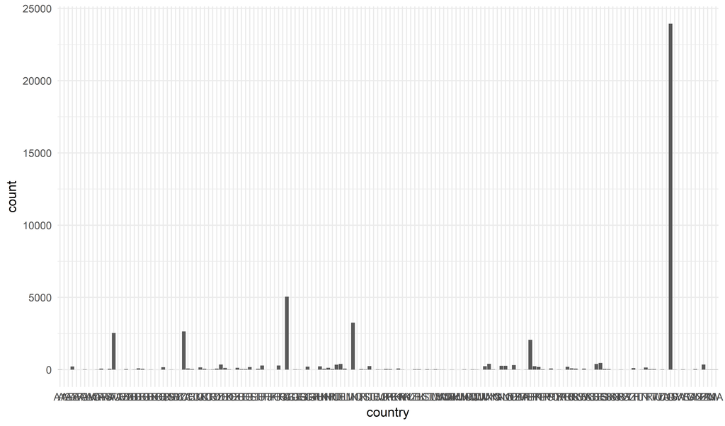

Fitting a model with all of these countries is possible but not very useful. When we only have a few responses from some places it makes those few regions with a lot of data harding to identify and analyze. Fortunately there is a solution in the function `fct_lump`.

Fit a regression model on the entire dataset by the country variable lumped into 5 categories.

```
##
## Call:
## lm_basic(formula = warmth ~ 1 + fct_lump(country, n = 5), data = pf)
##
## Residuals:
##      Min       1Q   Median       3Q      Max
## -13.1934  -1.0816   0.1697   1.0406   6.1697
##
## Coefficients:
##                               Estimate    2.5 % 97.5 %
## (Intercept)                   14.19345 14.11485 14.272
## fct_lump(country, n = 5)CA    -0.08515 -0.19517  0.025
## fct_lump(country, n = 5)GB    -0.11188 -0.20819 -0.016
## fct_lump(country, n = 5)IN    -0.23405 -0.33889 -0.129
## fct_lump(country, n = 5)US    -0.02413 -0.10679  0.059
## fct_lump(country, n = 5)Other -0.36311 -0.44985 -0.276
##
## Residual standard error: 2.018 on 49037 degrees of freedom
##   (17 observations deleted due to missingness)
## Multiple R-squared:  0.004908,   Adjusted R-squared:  0.004806
## F-statistic: 48.37 on 5 and 49037 DF,  p-value: < 2.2e-16
```

Using the previous model, which country (not including “Other”) has the highest score for your trait? Which has the lowest?

**Answer**: The country with the highest score appears to be Australia. Not including “other,” the country with the lowest average warmth rating appears to be India.

## Fitting Sensitivity Scores

Fit a model that predicts sensitivity as a function of the baseline score.

```
##
## Call:
## lm_basic(formula = sensitivity ~ 1 + baseline, data = pf)
##
## Residuals:
##     Min      1Q  Median      3Q     Max
## -7.3533 -0.8905  0.0477  0.9890  6.4613
##
## Coefficients:
##             Estimate   2.5 % 97.5 %
## (Intercept)  0.16645 0.03733  0.296
## baseline     0.93818 0.92830  0.948
##
## Residual standard error: 1.483 on 49058 degrees of freedom
## Multiple R-squared:  0.4139, Adjusted R-squared:  0.4139
## F-statistic: 3.465e+04 on 1 and 49058 DF,  p-value: < 2.2e-16
```

Is the slope statistically significantly different from 1? Why is this an interesting question in the context of the data?

**Answer**: Yes, the baseline slope is statistically significant. Particpants’ baseline scores increase at a significantly higher rate than their actual sensitivity score, which is interesting because one might expect sensitivty to be higher than the baseline because the baseline is a compilation of many traits that might work against each other in defining the overall rating, yet sensitivity is interestingly lower than even the baseline.

Fit a regression model that uses both gender and the baseline score to predict your trait.

```
##
## Call:
## lm_basic(formula = warmth ~ 1 + gender + baseline, data = pf)
##
## Residuals:
##     Min      1Q  Median      3Q     Max
## -8.9655 -0.9047  0.1438  1.0329  5.9550
##
## Coefficients:
##             Estimate   2.5 % 97.5 %
## (Intercept)   1.1750  1.0415  1.308
## gendermale   -0.2357 -0.2632 -0.208
## baseline      0.9984  0.9883  1.009
##
## Residual standard error: 1.517 on 49057 degrees of freedom
## Multiple R-squared:  0.4375, Adjusted R-squared:  0.4375
## F-statistic: 1.908e+04 on 2 and 49057 DF,  p-value: < 2.2e-16
```

Describe the slope for the gender term in words:

**Answer**: The slope for gender is negatively significant. This means that as one’s warmth and baseline score increase, the likelihood that that person is a male decreases at a significant rate of -0.2357.

Add predictions from the previous model to `pf`.

```
## # A tibble: 49,060 x 23
##      age gender country elapsed warmth reasoning emotional_stability
##    <int> <chr>  <chr>     <int>  <dbl>     <dbl>               <dbl>
##  1    17 male   US          914   12.0      14.0                15.0
##  2    37 male   US          891   14.0      13.0                12.0
##  3    31 male   US          903   14.0      14.0                12.0
##  4    32 male   US          806   14.0      15.0                12.0
##  5    46 female NZ         1826   13.0      15.0                14.0
##  6    36 female IT          669   15.0      12.0                11.0
##  7    35 male   US          717   13.0      14.0                12.0
##  8    61 female US          567   15.0      14.0                12.0
##  9    17 female US          651   15.0      15.0                12.0
## 10    19 male   US         1835   15.0      14.0                12.0
## # ... with 49,050 more rows, and 16 more variables: dominance <dbl>,
## #   liveliness <dbl>, rule_consciousness <dbl>, social_boldness <dbl>,
## #   sensitivity <dbl>, vigilance <dbl>, abstractedness <dbl>,
## #   privateness <dbl>, apprehension <dbl>, openness_to_change <dbl>,
## #   self_reliance <dbl>, perfectionism <dbl>, tension <dbl>,
## #   baseline <dbl>, model_warmth_gender_baseline_pred <dbl>,
## #   model_warmth_gender_baseline_resid <dbl>
```

```
##
## Call:
## lm_basic(formula = warmth ~ 1 + baseline + gender, data = pf)
##
## Residuals:
##     Min      1Q  Median      3Q     Max
## -8.9655 -0.9047  0.1438  1.0329  5.9550
##
## Coefficients:
##             Estimate   2.5 % 97.5 %
## (Intercept)   1.1750  1.0415  1.308
## baseline      0.9984  0.9883  1.009
## gendermale   -0.2357 -0.2632 -0.208
##
## Residual standard error: 1.517 on 49057 degrees of freedom
## Multiple R-squared:  0.4375, Adjusted R-squared:  0.4375
## F-statistic: 1.908e+04 on 2 and 49057 DF,  p-value: < 2.2e-16
```

Plot the baseline score as a function of `model_pred`, coloring the points base on the gender variable.

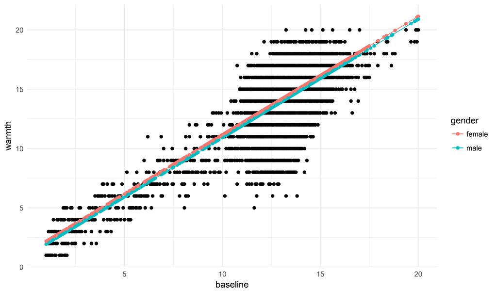

What do the predicted values look like?

**Answer**: For both males and females, warmth will increase as the baseline scores increase.